# Escapement Goal Visualizations for AFS

Madeline Jovanovich

4/5/2018

Story board out the talk: what do I want the take home message to be? -Introduction: lay the stage of the importance of an escapement focus; history, state statues quotes, policy that we must deal with escapement “give the importnace of escapement” -the move on the methods of countins -then move on to goals: how are they picked, what they mean, leading into a review of performance –after general overview, then move on the specific examples “other species are doing well” (show that) “but let’s take a look at chinook”

The following figures are printed in [Munro & Volk 2016](http://www.adfg.alaska.gov/FedAidPDFs/FMS16-04.pdf)

1. Summary of 300 goals in effect during the 2012 spawning season
   1. number goals by specie, type
2. Proportion of 49 goals by species in SE region
3. Proportion of 120 goals by species in Central region
4. Proportion of 72 goals by species in AYK reguib
5. Proportion of 59 goals by species in Westward
6. SE escapement compared to goals: 2004-2012
7. Central escapement compared to goals: 2004-2012
8. AYK escapement compared to goals: 2004-2012
9. Westward escapement compared to goals: 2004-2012
10. Statewide summary by year of % of escapements that
    1. met goal
    2. below lower bound of goal
    3. exceeded upper bount of goal

    For years 2004 through 2012

**Should I first recreate the figures in M&V, but with SASAP regions; then move on to plot how I would like?**

The following report will include figures that show escapement goal information reported by

1. SASAP region
   1. number of goals
   2. number rivers with goals
2. Location
3. Proportion of time goals were
   1. met
   2. exceeded upper bound
   3. below lower bound
   4. **what about range of years across regions?**
4. Locations with goals met
   1. escapement over time
   2. catch over time
5. Locations with goals exceeded
   1. escapement over time
   2. catch over time
6. Locations with goals below
   1. escapement over time
   2. catch over time
7. Compare locations with escapement information to those with goals (LocationID length = 360 and 229, respectively)

**Note: to include 5 and 6 from the above list, the [harvest data](https://knb.ecoinformatics.org/#view/urn:uuid:ed53e7bd-c798-4839-a955-ba8179ea1260) must be reformatted** I am interested in commercial catch, but should I show subsistence and sport as well? That may be too much to do.

Talking points: Look at the ADF&G booklet, quotes from first commissioner Hard and fast assessment of how many escapement goals are being met Show across the board, big scale overview opening: use this as a way to show what’s happening on the ground Use that as a segue to show what’s going on on the grounds What stocks are of harvest concern Spawner-recruit relationships: brood table plotting, plot recruit/spawner relationships from certain case studies, hard to see evidence of compensation (bending over of curb)

So what of overescpament? Daniel’s paleoecology paper in BB

Species comparison: are we doing better for sockeye, pinks, and chum than we are for chinook?

SEAK escapement issues: Chinook in Taku and Stikine -putting these inthe context of what the rest of the state is doing -overall state is doing well, but exceptions

Kuskokwim: compare chinook to other species

These visualizations are dependent on first running ~/sasap-data/data-processing/Escapement/GoalEvaluation.Rmd

The following read command is for mjovanvich’s local drive:

```r
esc_goals_evaluated <- read.csv(file='~/R/Esc_goals_evaluated.csv')
```

The following read command is for mjovanvich’s Aurora:

```r
esc_goals_evaluated <- read.csv(file='~/Escapement/Esc_goals_evaluated.csv')
```

```r
library(knitr)
library(dplyr)
library(tidyr)
library(ggplot2)
library(ggthemes)
library(RColorBrewer)
library(tables)
library(stargazer)
library(scales)
```

Creating proportions of time in which escapement goals were either met or not:

(Why did we not just scan these from the reports when we scanned the data?)

```r
#Need to write this code for the percents data, giving us a kable printout of:
#   number of goals met, exceeded, or below goals by region
#   number of goals by region (total)
#   number of escapement locations by region (comparing esc_goals to esc_goals_evaluated)
releases <- releases[!is.na(releases$ReleasedInd),]
str(returnsby_year)
range(returnsby_year$Year)
range(returnsby_year$TotalCatch)
tbl_df(returnsby_year)
summary(returnsby_year)

rby_sum <- returnsby_year %>%
    group_by(Region) %>%
    select(Year, TotalCatch) %>%
    summarise_all(funs(min = min,
                     max = max))
num_hatcheries <- returnsby_year %>%
    group_by(Region) %>%
    select(Hatchery, Project, Species) %>%
    summarise_all(funs(n_distinct))

dim(rby_sum)
dim(num_hatcheries)
summary <- left_join(rby_sum, num_hatcheries)
summary <- summary[,c(1,2,4,3,5,6,7,8)]

colnames(summary) <- (c("Region", "Year min", "Year max", "Min return", "Max return", "Hatchery", "Project", "Species"))
```

```r
kable(summary, caption = "Returns Summary")
```

[output not shown]

```r
kable(percents, caption = "Table with kable")
```

[output not shown]

#### Investigating escapement goals by region

Might be more useful to see # of rivers of each goal type by region

Then show table with range of years for each goal type by region

Then single out rivers of interest within that region

I don’t like how far down the x-axis label is

The following are similar to [Munro & Volk, 2016](http://www.adfg.alaska.gov/FedAidPDFs/FMS16-04.pdf) **be sure to track citations for talk**

Thinking about color scheme: is the following acceptable for color blind because it has different luminosities? I.e. even though it is blue, the blues are different (so they would be like grayscale)

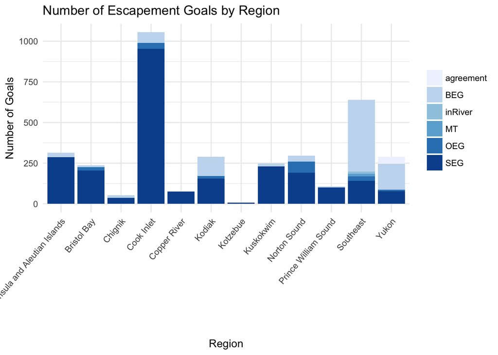

```r
ggplot(data = esc_goals_results, aes(x = SASAP.Region, fill=factor(types), y=(..count..))) +
    geom_bar() +
    xlab("Region") +
    ylab("Number of Goals") +
    ggtitle("Number of Escapement Goals by Region") +
    theme_minimal() +
    theme(axis.text.x = element_text(angle = 50, hjust = 1)) +
    scale_fill_brewer("Diamond\nclarity") +
    theme(legend.title=element_blank())
```

Why is the scale_color_colorblind() call not working?

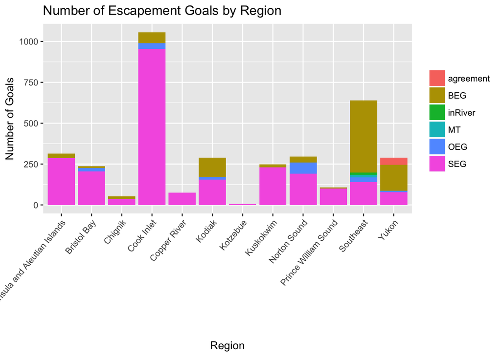

```r
ggplot(data = esc_goals_results, aes(x = SASAP.Region, fill=factor(types), y=(..count..))) +
    geom_bar() +
    xlab("Region") +
    ylab("Number of Goals") +
    ggtitle("Number of Escapement Goals by Region") +
    scale_color_colorblind() +
    theme(axis.text.x = element_text(angle = 50, hjust = 1)) +
    theme(legend.title=element_blank())
```

#### Proportion of goal achievement

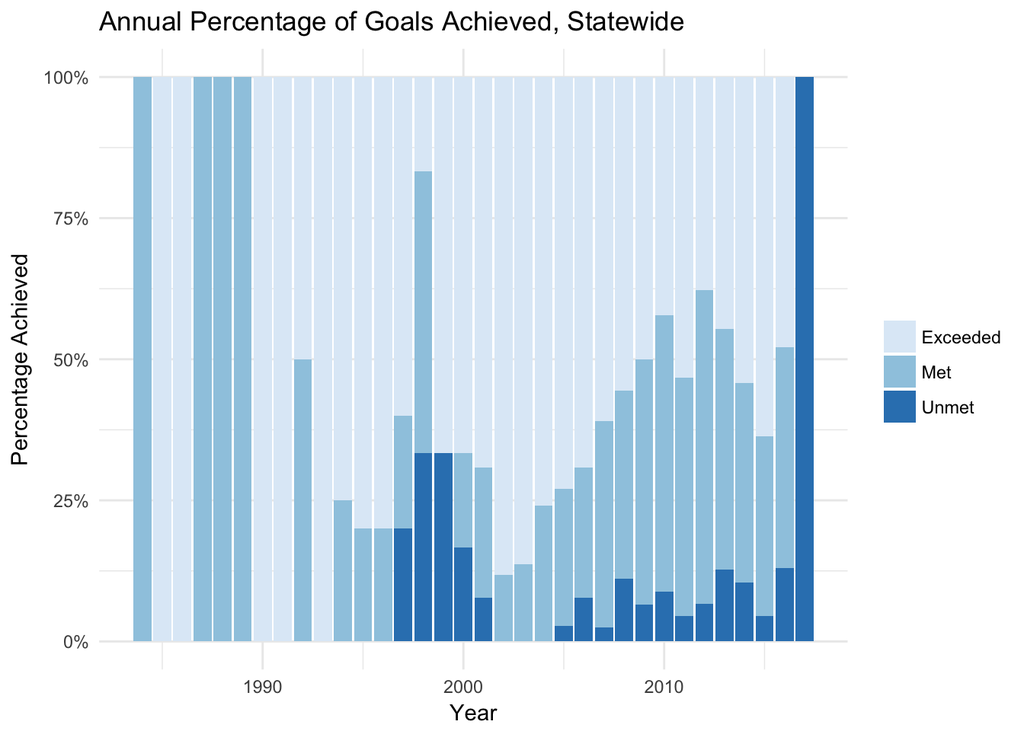

```r
ggplot(data = percents, aes(x = sampleYear, fill=factor(metUnmetExceeded), y=(..count..))) +
    geom_bar(position='fill') +
    xlab("Year") +
    ylab("Percentage Achieved") +
    ggtitle("Annual Percentage of Goals Achieved, Statewide") +
    scale_y_continuous(labels=scales::percent) +
    guides(fill=guide_legend(title="")) +
    theme_minimal() +
    scale_fill_brewer("Diamond\nclarity")
```

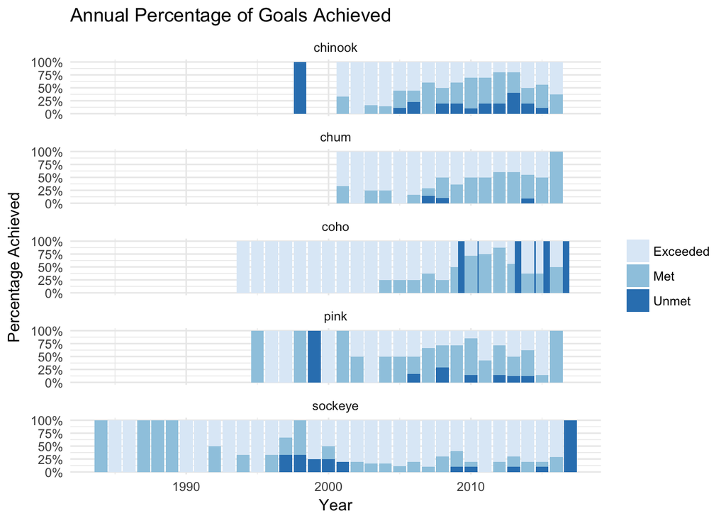

```r
#Now the y axis here is a bit ugly and needs to be stretched out, but it allows us to view the relative acheivement by year
#But now, since goals are set by location, viewing achievement by location and species would be more useful
#It would also be great to view likelihood/tendency to exceed the goal. "Goals are exceeded blank amount of time"
ggplot(data = percents, aes(x = sampleYear, fill=factor(metUnmetExceeded), y=(..count..))) +
    geom_bar(position='fill') +
    xlab("Year") +
    ylab("Percentage Achieved") +
    ggtitle("Annual Percentage of Goals Achieved") +
    scale_y_continuous(labels=scales::percent) +
    guides(fill=guide_legend(title="")) +
    facet_wrap(~Species, ncol=1, scales="free_y") +
    theme_minimal() +
    scale_fill_brewer("Diamond\nclarity")
```

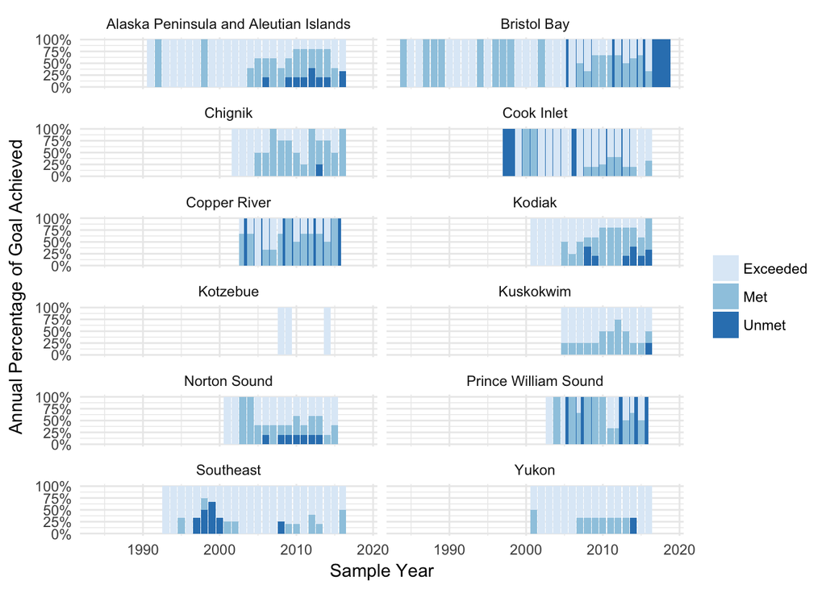

```r
#It's easier to compare by region and year with less columns, but we still need to stretch out the y axis
ggplot(data = percents, aes(x = sampleYear, fill=factor(metUnmetExceeded), y=(..count..))) +
    geom_bar(position='fill') +
    xlab("Sample Year") +
    ylab("Annual Percentage of Goal Achieved") +
    scale_y_continuous(labels=scales::percent) +
    guides(fill=guide_legend(title="")) +
    facet_wrap(~SASAP.Region, ncol = 2) +
    theme_minimal() +
    scale_fill_brewer("Diamond\nclarity")
```

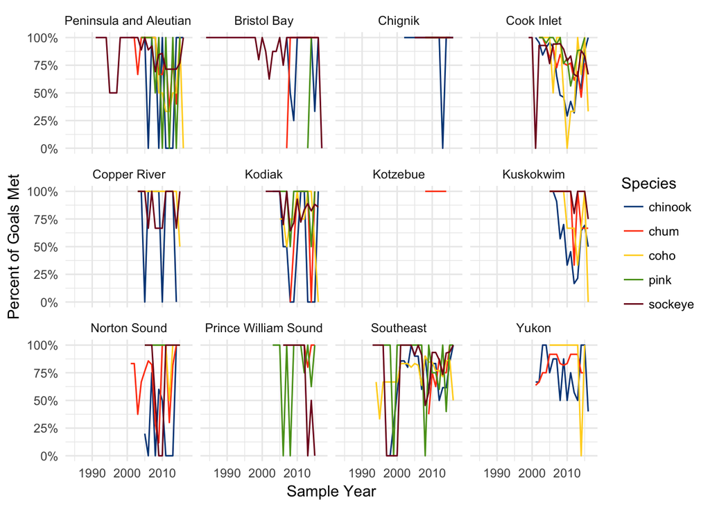

```r
ggplot(data = percents, aes(x = sampleYear, y = percentMetLower, color=Species)) +
    geom_line() +
    xlab("Sample Year") +
    ylab("Percent of Goals Met") +
    scale_y_continuous(labels=scales::percent) +
    facet_wrap(~SASAP.Region) +
    theme_minimal() +
    scale_color_calc()
```

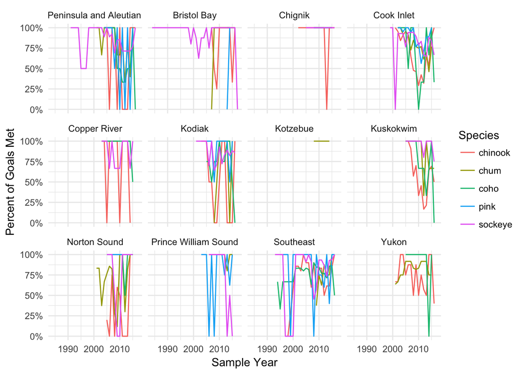

```r
# Percent of goals met over time, grouped by species
 ggplot(data = percents, aes(x = sampleYear, y = percentMetLower, color=Species)) +
     geom_line() +
     xlab("Sample Year") +
     ylab("Percent of Goals Met") +
     scale_y_continuous(labels=scales::percent) +
     facet_wrap(~SASAP.Region) +
     theme_minimal() +
    scale_fill_brewer("Diamond\nclarity")
```

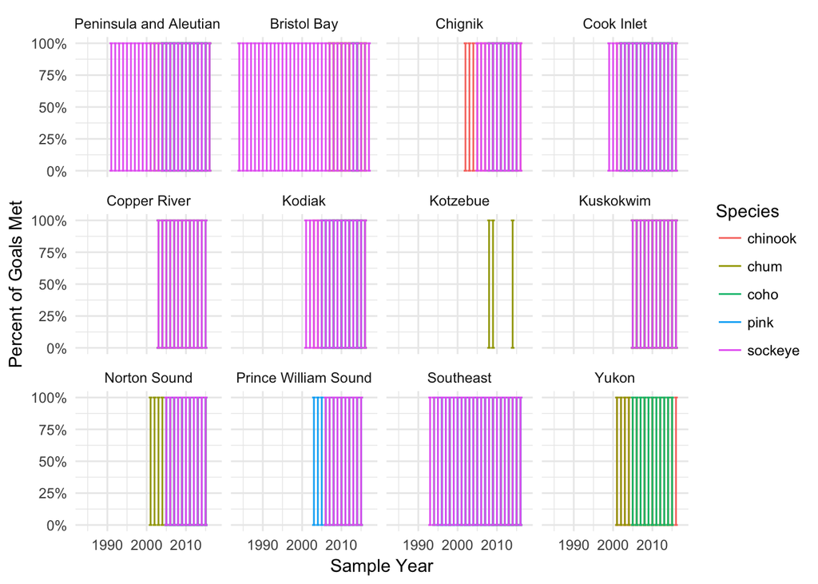

```r
#Trying to figure out a better way to visualize this. We can look at "unmet" and "exceeded" as error
# Percent of goals met over time, grouped by species
 ggplot(data = percents, aes(x = sampleYear, xmin=min(sampleYear), y = percentMetLower, ymin=min(percentMetLower), ymax=max(percentMetLower), color=Species)) +
     geom_errorbar() +
     xlab("Sample Year") +
     ylab("Percent of Goals Met") +
     scale_y_continuous(labels=scales::percent) +
     facet_wrap(~SASAP.Region) +
     theme_minimal() +
    scale_fill_brewer("Diamond\nclarity")
```